# HW 9 Solutions

## Question 1

### (a) (2 pts)

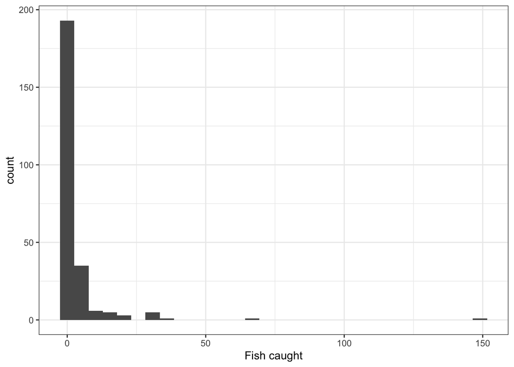

```r
fish %>%
  ggplot(aes(x = count)) +
  geom_histogram() +
  theme_bw() +
  labs(x = "Fish caught")
```

### (b) (2 pts)

The number of fish caught is right skewed, with a large peak at 0 (indeed, over 50% of the groups caught 0 fish). With so many 0s in the data, a Poisson distribution will be a poor fit, and a zero-inflated model will be needed to handle the excess 0s. Here the latent variable would indicate whether the group ever fished during their stay ($Z_i = 0$ if they fished, and $Z_i = 1$ if they never went fishing).

**Grading:** 1 pt for noting the excess 0s and connecting the excess 0s to a zero-inflated model; 1 pt for the latent variable. It is possible that students will propose a different latent variable, which is ok as long as the latent variable is reasonable. I think the most natural latent variable here is whether or not they go fishing.

### (c) (2 pts)

Offsets are used to account for different exposures, i.e. different amounts of opportunity to observe the response. In this case, groups who stay longer have more time to catch fish, and comparing the raw number of fish caught between groups who stayed one day vs. groups who stayed 10 days doesn’t really make sense. Rather, it makes more sense to compare the number of fish caught *per day*, thus accounting for the length of stay. Using an offset allows us to interpret the model in terms of the rate of fish caught per day, rather than the raw number of fish caught.

**Grading:** Answers may vary somewhat here. The point is that people who visit for longer have more opportunity to catch fish.

## Question 2

### (a) (3 pts)

Let $Y_i$ denote the number of fish caught per group. Then

$P(Y_i = y) = \begin{cases} e^{-\lambda_i}(1 - \alpha_i) + \alpha_i & y = 0 \\ \dfrac{e^{-\lambda_i} \lambda_i^y}{y!}(1 - \alpha_i) & y > 0 \end{cases}$

where

$\log \left( \dfrac{\alpha_i}{1 - \alpha_i} \right) = \gamma_0 + \gamma_1 Camper_i + \gamma_2 Child_i + \gamma_3 Persons_i$

$\log \left( \lambda_i \right) = \beta_0 + \beta_1 Camper_i + \beta_2 Child_i + \beta_3 Persons_i + \log(LOS)$

**Grading:** Lose 1 pt if missing/incorrect random component. Lose 1 pt if missing/incorrect logistic or Poisson parts of the ZIP model. Lose 1 pt for incorrect notation.

### (b) (2 pts)

```r
m1 <- zeroinfl(count ~ camper + child + persons | camper + child + persons,
               offset = log(LOS),
               data = fish)
summary(m1)
```

```
##
## Call:
## zeroinfl(formula = count ~ camper + child + persons | camper + child +
##     persons, data = fish, offset = log(LOS))
##
## Pearson residuals:
##       Min        1Q    Median        3Q       Max
## -2.073183 -0.740560 -0.358079 -0.001489 10.738599
##
## Count model coefficients (poisson with log link):
##             Estimate Std. Error z value Pr(>|z|)
## (Intercept) -1.12953    0.16110  -7.011 2.36e-12 ***
## camper       0.01754    0.09563   0.183    0.855
## child       -0.56379    0.09158  -6.156 7.44e-10 ***
## persons      0.45097    0.04378  10.302  < 2e-16 ***
##
## Zero-inflation model coefficients (binomial with logit link):
##             Estimate Std. Error z value Pr(>|z|)
## (Intercept)   1.8052     0.5224   3.456 0.000549 ***
## camper       -1.1632     0.3735  -3.114 0.001846 **
## child         2.0813     0.3465   6.007 1.90e-09 ***
## persons      -0.9764     0.2128  -4.588 4.48e-06 ***
## ---
## Signif. codes:  0 '***' 0.001 '**' 0.01 '*' 0.05 '.' 0.1 ' ' 1
##
## Number of iterations in BFGS optimization: 13
## Log-likelihood: -501.1 on 8 Df
```

### (c) (2 pts)

An increase of one in the number of children in the group is associated with an increase in the odds that the group did not fish by a factor of $\exp\{2.08\} = 8$, and a decrease in the number of fish caught *per day*, for groups which *did* fish, by a factor of $\exp\{-0.56\} = 0.57$.

**Grading:** 1 pt for logistic part, 1 pt for Poisson part. It is ok if they interpret on the log-odds or log-mean scale.

### (d) (2 pts)

```r
2.08 + 1.96*0.35
```

```
## [1] 2.766
```

```r
2.08 - 1.96*0.35
```

```
## [1] 1.394
```

```r
-0.56 + 1.96*0.09
```

```
## [1] -0.3836
```

```r
-0.56 - 1.96*0.09
```

```
## [1] -0.7364
```

**Grading:** 1 pt for each confidence interval.

## Question 3

### (a) (3 pts)

$P(Y_i \geq 1) = 1 - P(Y_i = 0) = 1 - (e^{-\lambda_i}(1 - \alpha_i) + \alpha_i)$

So we need to calculate $\widehat{\alpha}_i$ and $\widehat{\lambda}_i$. We are told that $Persons = 3$, $Child = 0$, $Camper = 0$, and $LOS = 3$. So,

$\log \left( \dfrac{\widehat{\alpha}_i}{1 - \widehat{\alpha}_i} \right) = 1.81 - 0.98(3) = -1.13$

and thus $\widehat{\alpha}_i = 0.244$. Similarly,

$\log (\widehat{\lambda}_i) = -1.13 + 0.45(3) + log(3) = 1.32$

and so $\widehat{\lambda}_i = 3.74$. The estimated probability of catching at least one fish is therefore $1 - (e^{-3.74}(1 - 0.244) + 0.244) = 0.74$.

**Grading:** 1 pt for calculating $\alpha$, 1 pt for calculating $\lambda$, 1 pt for correctly combining them.

Some potential errors: students might calculate $P(Y_i = 1)$ instead of $P(Y_i \geq 1)$; students might misinterpret $\widehat{\alpha}_i$ as the probability of catching fish, rather than the probability of not going fishing.

### (b) (3 pts)

The estimated number of fish caught *by a group that went fishing* is $\widehat{\lambda}_i$. However, we don’t know whether the group went fishing or not, so we have to weight this number of the probability they went fishing ($1 - \alpha_i$). Thus the estimated number of fish caught is $\widehat{\lambda}_i(1 - \widehat{\alpha}_i)$.

Here

$\log \left( \dfrac{\widehat{\alpha}_i}{1 - \widehat{\alpha}_i} \right) = 1.81 - 1.16 + 2.08(3) - 0.98(5) = 1.99$

so $\widehat{\alpha}_i = 0.88$. Similarly,

$\log (\widehat{\lambda}_i) = -1.13 + 0.018 - 0.56(3) + 0.45(5) + log(7) = 1.4$

so $\widehat{\lambda}_i = 4.1$. Thus, the estimated number of fish caught is $4.1(1 - 0.88) = 0.49$.

**Grading:** 1 pt for calculating $\alpha$, 1 pt for calculating $\lambda$, 1 pt for correctly combining them.

## Question 4

### (a) (3 pts)

We are interested in testing the coefficient on $Child$ for the logistic part of the model. Using the model from question 2, our hypotheses are $H_0: \gamma_2 = 0$ vs. $H_A: \gamma_2 > 0$ (remember that the logistic component models the probability the group does *not* go fishing). We use a Wald test; the test statistic is 6.01, and the p-value is

```r
pnorm(6.01, lower.tail=F)
```

```
## [1] 9.276166e-10
```

**Grading:** Lose 1 pt if testing the wrong part of the ZIP model. Lose 1 pt if testing the wrong direction for the alternative hypothesis. Lose 1 pt if they use a LRT instead of a Wald test.

### (b) (3 pts)

We are interested in testing the coefficient on $Child$ in the Poisson part of the ZIP model. Using the model from question 2, our hypotheses are $H_0: \beta_2 = 0$ vs. $H_A: \beta_2 < 0$. We use a Wald test; the test statistic is -6.16, and the p-value is

```r
pnorm(-6.16, lower.tail=T)
```

```
## [1] 3.637247e-10
```

**Grading:** Lose 1 pt if testing the wrong part of the ZIP model. Lose 1 pt if testing the wrong direction for the alternative hypothesis. Lose 1 pt if they use a LRT instead of a Wald test.

## Question 5

### (a) (2 pts)

```r
# simulate data
set.seed(3)
n <- 1000
x <- rnorm(n)
gamma0 <- 0
beta0 <- 1
beta1 <- 1
alpha <- exp(gamma0)/(1 + exp(gamma0))
lambda <- exp(beta0 + beta1*x)
z <- rbinom(n, 1, prob=alpha)
y <- 0*z + rpois(n, lambda)*(1 - z)

# fit Poisson and ZIP models
m_pois <- glm(y ~ x, family = poisson)
m_zip <- zeroinfl(y ~ x | x)

summary(m_pois)
```

```
##
## Call:
## glm(formula = y ~ x, family = poisson)
##
## Deviance Residuals:
##     Min       1Q   Median       3Q      Max
## -9.0240  -1.6651  -0.9271   0.9289   6.2820
##
## Coefficients:
##             Estimate Std. Error z value Pr(>|z|)
## (Intercept)  0.26451    0.03044   8.691   <2e-16 ***
## x            0.97807    0.02139  45.725   <2e-16 ***
## ---
## Signif. codes:  0 '***' 0.001 '**' 0.01 '*' 0.05 '.' 0.1 ' ' 1
##
## (Dispersion parameter for poisson family taken to be 1)
##
##     Null deviance: 5749.4  on 999  degrees of freedom
## Residual deviance: 3680.3  on 998  degrees of freedom
## AIC: 4935
##
## Number of Fisher Scoring iterations: 6
```

```r
summary(m_zip)
```

```
##
## Call:
## zeroinfl(formula = y ~ x | x)
##
## Pearson residuals:
##     Min      1Q  Median      3Q     Max
## -1.0328 -0.7324 -0.5052  0.6617  5.3922
##
## Count model coefficients (poisson with log link):
##             Estimate Std. Error z value Pr(>|z|)
## (Intercept)  0.94767    0.03766   25.16   <2e-16 ***
## x            1.04129    0.02692   38.68   <2e-16 ***
##
## Zero-inflation model coefficients (binomial with logit link):
##             Estimate Std. Error z value Pr(>|z|)
## (Intercept)  0.10033    0.08165   1.229    0.219
## x           -0.05271    0.08666  -0.608    0.543
## ---
## Signif. codes:  0 '***' 0.001 '**' 0.01 '*' 0.05 '.' 0.1 ' ' 1
##
## Number of iterations in BFGS optimization: 9
## Log-likelihood: -1384 on 4 Df
```

For the slope, the Poisson estimate is $\widehat{\beta}_1 = 0.98$ and the ZIP estimate is $\widehat{\beta}_1 = 1.04$, so both are pretty close to $\beta_1 = 1$. However, for the intercept $\widehat{\beta}_0 = 0.26$ for the Poisson model, whereas $\widehat{\beta}_0 = 0.95$ for the ZIP model; the ZIP estimate is much closer to $\beta_0 = 1$.

**Grading:** 1 pt for running code, 1 pt for comparing estimates to true values.

### (b) (2 pts)

```r
upper_poisson <- summary(m_pois)$coefficients[2,1] +
    1.96*summary(m_pois)$coefficients[2,2]
lower_poisson <- summary(m_pois)$coefficients[2,1] -
    1.96*summary(m_pois)$coefficients[2,2]

upper_poisson > 1 & lower_poisson < 1
```

```
## [1] TRUE
```

Yes, the interval contains $\beta_1$ (answer will vary).

### (c) (2 pts)

```r
upper_zip <- summary(m_zip)$coefficients$count[2,1] +
    1.96*summary(m_zip)$coefficients$count[2,2]
lower_zip <- summary(m_zip)$coefficients$count[2,1] -
    1.96*summary(m_zip)$coefficients$count[2,2]

upper_zip > 1 & lower_zip < 1
```

```
## [1] TRUE
```

Yes, the interval contains $\beta_1$ (answer will vary).

**Grading:** Lose 1 pt for using the wrong part of the ZIP model.

## Question 6 (5 pts)

```r
set.seed(3)
nsim <- 1000
n <- 1000
gamma0 <- 0
beta0 <- 1
beta1 <- 1

covers_zip <- rep(NA, nsim)
covers_poisson <- rep(NA, nsim)

for(i in 1:nsim){
  x <- rnorm(n)
  alpha <- exp(gamma0)/(1 + exp(gamma0))
  lambda <- exp(beta0 + beta1*x)
  z <- rbinom(n, 1, prob=alpha)
  y <- 0*z + rpois(n, lambda)*(1 - z)

  # fit Poisson and ZIP models
  m_pois <- glm(y ~ x, family = poisson)
  m_zip <- zeroinfl(y ~ x | x)

  upper_zip <- summary(m_zip)$coefficients$count[2,1] +
      1.96*summary(m_zip)$coefficients$count[2,2]
  lower_zip <- summary(m_zip)$coefficients$count[2,1] -
      1.96*summary(m_zip)$coefficients$count[2,2]

  covers_zip[i] <- upper_zip > 1 & lower_zip < 1

  upper_poisson <- summary(m_pois)$coefficients[2,1] +
      1.96*summary(m_pois)$coefficients[2,2]
  lower_poisson <- summary(m_pois)$coefficients[2,1] -
      1.96*summary(m_pois)$coefficients[2,2]

  covers_poisson[i] <- upper_poisson > 1 & lower_poisson < 1
}

mean(covers_poisson)
```

```
## [1] 0.409
```

```r
mean(covers_zip)
```

```
## [1] 0.94
```

Coverage is around 40% for the Poisson model, and around 95% for the ZIP model (students’ numbers will vary slightly, but there should be a big difference in the coverage here).

**Grading:** If their coverage values are substantially different from these numbers, something has gone wrong. Coverage for the Poisson should be much lower than for the ZIP model, and coverage for the ZIP model should be around 95%.

## Question 7

### (a) (5 pts)

```r
set.seed(3)
nsim <- 1000
n <- 1000
beta0 <- 1
beta1 <- 1

gamma0_values <- seq(-2, 2, 0.5)
coverage_poisson <- rep(NA, length(gamma0_values))
coverage_zip <- rep(NA, length(gamma0_values))

for(j in 1:length(gamma0_values)){
  gamma0 <- gamma0_values[j]

  covers_zip <- rep(NA, nsim)
  covers_poisson <- rep(NA, nsim)

  for(i in 1:nsim){
    x <- rnorm(n)
    alpha <- exp(gamma0)/(1 + exp(gamma0))
    lambda <- exp(beta0 + beta1*x)
    z <- rbinom(n, 1, prob=alpha)
    y <- 0*z + rpois(n, lambda)*(1 - z)

    # fit Poisson and ZIP models
    m_pois <- glm(y ~ x, family = poisson)
    m_zip <- zeroinfl(y ~ x | x)

    upper_zip <- summary(m_zip)$coefficients$count[2,1] +
        1.96*summary(m_zip)$coefficients$count[2,2]
    lower_zip <- summary(m_zip)$coefficients$count[2,1] -
        1.96*summary(m_zip)$coefficients$count[2,2]

    covers_zip[i] <- upper_zip > 1 & lower_zip < 1

    upper_poisson <- summary(m_pois)$coefficients[2,1] +
        1.96*summary(m_pois)$coefficients[2,2]
    lower_poisson <- summary(m_pois)$coefficients[2,1] -
        1.96*summary(m_pois)$coefficients[2,2]

    covers_poisson[i] <- upper_poisson > 1 & lower_poisson < 1
  }

  coverage_poisson[j] <- mean(covers_poisson)
  coverage_zip[j] <- mean(covers_zip)
}
```

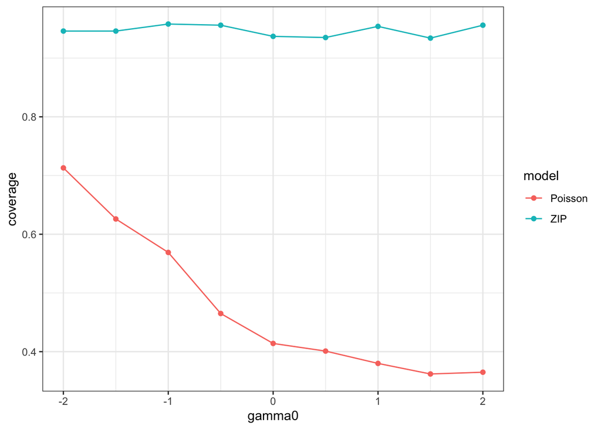

```r
data.frame(gamma0 = c(gamma0_values, gamma0_values),
           coverage = c(coverage_poisson, coverage_zip),
           model = rep(c("Poisson", "ZIP"), each=length(gamma0_values))) %>%
  ggplot(aes(x = gamma0, y = coverage, color = model)) +
  geom_point() +
  geom_line() +
  theme_bw()
```

**Grading:** It is ok if they use different values of $\gamma_0$, provided they choose a range of values. However, the general pattern should be the same as the results shown here; if not, something has probably gone wrong with their code.

They don’t have to use a nested for loop.

### (b) (2 pts)

Coverage for the ZIP model is constant around 95%, but coverage for the Poisson model is lower. Coverage for the Poisson model decreases as $\gamma_0$ (i.e., the amount of zero-inflation) increases.